# An Introduction to hpgltools Usage

atb abelew@gmail.com

2016-04-27

# Hpgltools: helper functions for RNAseq data analysis

This document is intended to demonstrate the ways the hpgltools package may help ease high-throughput data analyses. To that end a few examples will be performed using it using data from my work including:

- RNA sequencing analysis
- Ribosome profiling analysis
- Transposon insertion library analyses

When performing these tasks, I use this package for:

- Data distribution visualization and analysis
- Batch effect quantification
- Differential expression analyses with DESeq2/EdgeR/limma and comparisons among them
- Gene Ontology representation via goseq, clusterProfiler, topGO, GOStats, and gProfiler
- KEGG visualization
- (Bacterial) visualization with circos
- Limited motif/ARE searching
- Data export to excel

# Getting ready

Installation of hpgltools is fairly simple

```r
## The easiest way to install hpgltools is via devtools
install.packages("devtools")
devtools::install_github("abelew/hpgltools")
library(hpgltools)
```

It uses many R packages, which are annoying to install piecemeal, therefore it has the function autoload_all() to help.

```r
library(hpgltools)
## If uncommented, the following line queries the libraries used by hpgltools
## and if they are not available, installs them.

hpgltools::autoloads_all()

## shortcuts for using bioconductor's biocLite() and install_github()
hpgltools::require.auto("elsayedlab/TxDb.LmajorFriedlin.tritryp27.genes") ## Uses install_github()
hpgltools::require.auto("dplyr", update=TRUE) ## uses biocLite() and looks for packages to update.
```

Now that hpgltools has been loaded, let us load an experimental design, count tables, and annotation data.

# Loading data

In each of the examples above the following pieces of information are required:

- Annontation data as a df or gff (optional but useful)
- Experimental design as csv, excel, or df
- Count tables as a set of files 1/sample or df

## Human macrophage data loading

```r
library(hpgltools)
setwd("~/scratch/rnaseq_lpanamensis")
lp_gff <- "reference/lpanamensis.gff"
hs_gff <- "reference/hsapiens.gff"
lp_annotations <- gff2df(lp_gff, type="gene")
hs_annotations <- get_biomart_annotations()
```

```
## Finished downloading ensembl annotations.
```

```r
head(hs_annotations)
```

```
##                              ID hgnc_symbol
## ENSG00000210049 ENSG00000210049       MT-TF
## ENSG00000211459 ENSG00000211459     MT-RNR1
## ENSG00000210077 ENSG00000210077       MT-TV
## ENSG00000210082 ENSG00000210082     MT-RNR2
## ENSG00000209082 ENSG00000209082      MT-TL1
## ENSG00000198888 ENSG00000198888      MT-ND1
##                                                                                       Description
## ENSG00000210049     mitochondrially encoded tRNA phenylalanine [Source:HGNC Symbol;Acc:HGNC:7481]
## ENSG00000211459                mitochondrially encoded 12S RNA [Source:HGNC Symbol;Acc:HGNC:7470]
## ENSG00000210077            mitochondrially encoded tRNA valine [Source:HGNC Symbol;Acc:HGNC:7500]
## ENSG00000210082                mitochondrially encoded 16S RNA [Source:HGNC Symbol;Acc:HGNC:7471]
## ENSG00000209082 mitochondrially encoded tRNA leucine 1 (UUA/G) [Source:HGNC Symbol;Acc:HGNC:7490]
## ENSG00000198888   mitochondrially encoded NADH dehydrogenase 1 [Source:HGNC Symbol;Acc:HGNC:7455]
##                           Type
## ENSG00000210049        Mt_tRNA
## ENSG00000211459        Mt_rRNA
## ENSG00000210077        Mt_tRNA
## ENSG00000210082        Mt_rRNA
## ENSG00000209082        Mt_tRNA
## ENSG00000198888 protein_coding
```

```r
lp_goids <- read.csv(file="reference/lpan_go.txt.xz", sep="\t", header=FALSE)
colnames(lp_goids) <- c("ID","GO","ont","name","source","tag")

hs_inf_lp <- suppressMessages(create_expt(file="all_samples-hsapiens.xlsx"))
lp_alone <- suppressMessages(create_expt(file="all_samples-lpanamensis.xlsx"))
summary(hs_inf_lp)
```

```
##                        Length Class         Mode
## initial_metadata        5     data.frame    list
## original_expressionset  1     ExpressionSet S4
## expressionset           1     ExpressionSet S4
## design                 38     data.frame    list
## conditions             50     factor        numeric
## batches                50     factor        numeric
## samplenames            50     -none-        character
## colors                 50     -none-        character
## state                   5     -none-        list
## original_libsize       50     -none-        numeric
## libsize                 0     -none-        NULL
```

```r
knitr::kable(head(hs_inf_lp$design))
```

|  | sampleid | x2 | tubelabel | alias | condition | batch | anotherbatch | volunteer | time | snpstate | snpcategory | pctmappedparasite | pctcategory | state | sourcelab | exptdate | expperson | pathogen | pathogenstrain | noofpathogens | host | hostcelltype | noofhostcells | infectionperiodhpitimeofharvest | moiexposure | parasitespercell | pctinf | rnangul | rnaqcpassed | … |
| --- | --- | --- | --- | --- | --- | --- | --- | --- | --- | --- | --- | --- | --- | --- | --- | --- | --- | --- | --- | --- | --- | --- | --- | --- | --- | --- | --- | --- | --- | --- |
| HPGL0241 | HPGL0241 |  | TM130-Nil (Blue label) | Nil | macro_nil | a | a | 130 | NA | undef | 0 | undef | 0 | uninfected | Ade | NA | Adriana | none | none | NA | Human | Human macs | Max 2 mill | 2h - 24h chase period | NA | unknown | unknown | 468 | Y | … |
| HPGL0637 | HPGL0637 | NA | TM130-Nil (black label) | Nil | macro_nil | bb | b | 130 | NA | undef | 0 | undef | 0 | uninfected | Ade | NA | Adriana | none | none | NA | Human | Human macs | Max 2 mill | 2h - 24h chase period | NA | unknown | unknown | 32 | Y | … |
| HPGL0242 | HPGL0242 | NA | TM130-2271 | Self-Healing | macro_sh | a | a | 130 | NA | 5b | 2 | 30 | 3 | self_heal | Ade | NA | Adriana | Lp | 2271 | NA | Human | Human macs | Max 2 mill | 2h - 24h chase period | 4.8611111111111112E-2 | unknown | unknown | 276 | Y | … |
| HPGL0243 | HPGL0243 | NA | TM130-2272 | Self-Healing | macro_sh | a | a | 130 | NA | 6b | 2 | 30 | 3 | self_heal | Ade | NA | Adriana | Lp | 2272 | NA | Human | Human macs | Max 2 mill | 2h - 24h chase period | 4.8611111111111112E-2 | unknown | unknown | 532 | Y | … |
| HPGL0638 | HPGL0638 | NA | TM130-2189 | Self-Healing | macro_sh | bb | b | 130 | NA | 1a | 1 | 55 | 5 | self_heal | Ade | NA | Adriana | Lp | 2189 | NA | Human | Human macs | Max 2 mill | 2h - 24h chase period | 4.8611111111111112E-2 | unknown | unknown | 37 | Y | … |
| HPGL0639 | HPGL0639 | NA | TM130-1022 | Self-Healing | macro_sh | bb | b | 130 | NA | 32e | 4 | 30 | 3 | self_heal | Ade | NA | Adriana | Lp | 1022 | NA | Human | Human macs | Max 2 mill | 2h - 24h chase period | 4.8611111111111112E-2 | unknown | unknown | 54 | Y | … |

```r
dim(Biobase::exprs(hs_inf_lp$expressionset))
```

```
## [1] 51041    50
```

```r
library(org.Hs.eg.db)
hs_go_ensembl <-load_go_terms(org.Hs.eg.db, hs_annotations$ID)
hs_goids <- hs_go_ensembl[, c("ENSEMBL","GO")]
colnames(hs_goids) <- c("ID","GO")
```

This infection experiment contains 51,041 genes in 50 samples.

A couple of notes about create_expt:

1. It requires either a csv or xlsx metadata input file *or* a data frame of metadata.
2. If that metadata contains a ‘file’ column, it will attempt to read the files therein, if not it will search the ‘processed/count_tables’ directory for something making sense organised either by sample name. It assumes count tables are gzipped.
3. It will assign a set of colors with RColorBrewer, but accepts chosen colors
4. It is happiest with a df of metadata describing the genes, but that is not necessary
5. Upon completion, it keeps the experimental metadata in expt$design
6. It keeps a bioconductor Expressionset in expt$expressionset
7. It maintains the normalization etc. state of the data in expt$state
8. It keeps a backup of the expressionset in expt$original_expressionset

## Subsetting a large experimental design into smaller pieces

The human infection experiment loaded above is entirely too complex. Lets extract from it a portion of samples with interesting data While at it, lets also change the colors.

```r
hs_inf_lp_sub <- hpgltools::expt_subset(hs_inf_lp, subset="condition=='macro_nil'|condition=='macro_sh'|condition=='macro_ch'")
hs_inf_lp_sub$colors <- gsub(pattern="1B9E77", replacement="005500", x=hs_inf_lp_sub$colors)
hs_inf_lp_sub$colors <- gsub(pattern="817C37", replacement="880000", x=hs_inf_lp_sub$colors)
hs_inf_lp_sub$colors <- gsub(pattern="D1600F", replacement="0000FF", x=hs_inf_lp_sub$colors)
dim(Biobase::exprs(hs_inf_lp_sub$expressionset))
```

```
## [1] 51041    11
```

## Switching gears to yeast

Let us load a data set of yeast data. This data is rather simpler, no batch effect and fewer samples. In addition, the count tables are in the processed/ tree rather than the df.

```r
setwd("~/scratch/rnaseq_cbf5")
sc = create_expt(file="cbf5_samples.csv", file_suffix="_forward-trimmed-v0M1.count.gz", by_sample=TRUE)
```

```
## processed_data/count_tables/hpgl0564/hpgl0564_forward-trimmed-v0M1.count.gz contains 6697 rows.
```

```
## processed_data/count_tables/hpgl0565/hpgl0565_forward-trimmed-v0M1.count.gz contains 6697 rows and merges to 6697 rows.
```

```
## processed_data/count_tables/hpgl0566/hpgl0566_forward-trimmed-v0M1.count.gz contains 6697 rows and merges to 6697 rows.
```

```
## processed_data/count_tables/hpgl0567/hpgl0567_forward-trimmed-v0M1.count.gz contains 6697 rows and merges to 6697 rows.
```

```
## processed_data/count_tables/hpgl0568/hpgl0568_forward-trimmed-v0M1.count.gz contains 6697 rows and merges to 6697 rows.
```

```
## processed_data/count_tables/hpgl0569/hpgl0569_forward-trimmed-v0M1.count.gz contains 6697 rows and merges to 6697 rows.
```

```
## processed_data/count_tables/hpgl0570/hpgl0570_forward-trimmed-v0M1.count.gz contains 6697 rows and merges to 6697 rows.
```

```
## processed_data/count_tables/hpgl0571/hpgl0571_forward-trimmed-v0M1.count.gz contains 6697 rows and merges to 6697 rows.
```

```r
sc_genelengths = hpgltools::get_genelengths("reference/scerevisiae.gff.gz")
sc_goids = read.delim("reference/go_trimmed.csv.gz", sep=",")
colnames(sc_goids) = c("ID","GO","Yeast_ID")
knitr::kable(sc$design)
```

|  | sampleid | strain | condition | batch | tube | conc | bttotalreads | bttotalmapped | btleftmapped | btrightmapped | file | intercounts |
| --- | --- | --- | --- | --- | --- | --- | --- | --- | --- | --- | --- | --- |
| hpgl0564 | hpgl0564 | yJD1524 | wt | 1 | A | 619.4 | 27385278 | 23432324 | 15438470 | 11946808 | processed_data/count_tables/hpgl0564/hpgl0564_forward-trimmed-v0M1.count.gz | unknown |
| hpgl0565 | hpgl0565 | yJD1524 | wt | 1 | B | 629.0 | 17813593 | 15224673 | 10061396 | 7752197 | processed_data/count_tables/hpgl0565/hpgl0565_forward-trimmed-v0M1.count.gz | unknown |
| hpgl0566 | hpgl0566 | yJD1524 | wt | 1 | E | 375.4 | 8973978 | 7682107 | 5078415 | 3895563 | processed_data/count_tables/hpgl0566/hpgl0566_forward-trimmed-v0M1.count.gz | unknown |
| hpgl0567 | hpgl0567 | yJD1524 | wt | 1 | F | 720.3 | 23744501 | 20191005 | 13457860 | 10286641 | processed_data/count_tables/hpgl0567/hpgl0567_forward-trimmed-v0M1.count.gz | unknown |
| hpgl0568 | hpgl0568 | yJD1525 | mut | 1 | B | 440.7 | 23311126 | 19999162 | 13141126 | 10170000 | processed_data/count_tables/hpgl0568/hpgl0568_forward-trimmed-v0M1.count.gz | unknown |
| hpgl0569 | hpgl0569 | yJD1525 | mut | 1 | C | 423.5 | 10683277 | 9147161 | 6034715 | 4648562 | processed_data/count_tables/hpgl0569/hpgl0569_forward-trimmed-v0M1.count.gz | unknown |
| hpgl0570 | hpgl0570 | yJD1525 | mut | 1 | D | 580.6 | 29210067 | 25031349 | 16486811 | 12723256 | processed_data/count_tables/hpgl0570/hpgl0570_forward-trimmed-v0M1.count.gz | unknown |
| hpgl0571 | hpgl0571 | yJD1525 | mut | 1 | E | 433.8 | 10130466 | 8630359 | 5743359 | 4387107 | processed_data/count_tables/hpgl0571/hpgl0571_forward-trimmed-v0M1.count.gz | unknown |

file_suffix and file_prefix allow some flexibility in searching for filenames.

## How about bacteria?

Thus in the bacterial data set, we use both.

```r
setwd("~/scratch/rnaseq_mga")
sp <- suppressMessages(create_expt(file="all_samples.csv", sep="\t", file_prefix="07v2M1gen_", file_suffix="_genome.count.gz"))
knitr::kable(sp$design)
```

|  | sampleid | type | condition | batch | media | sra | readspassed | ncrna | xncrna | remaining | genome | xgenome | otherbacterial | xother | file | intercounts |
| --- | --- | --- | --- | --- | --- | --- | --- | --- | --- | --- | --- | --- | --- | --- | --- | --- |
| HPGL0406 | HPGL0406 | WT | EL | 1 | THY | NA | 19026277 | 353992 | 1.86% | 18672285 | 17810587 | 95.39% | 366984 | 1.97% | processed_data/count_tables/HPGL0406/07v2M1gen_HPGL0406_genome.count.gz | unknown |
| HPGL0407 | HPGL0407 | WT | EL | 2 | THY | NA | 15074073 | 259613 | 1.72% | 14814460 | 14334043 | 96.76% | 269649 | 1.82% | processed_data/count_tables/HPGL0407/07v2M1gen_HPGL0407_genome.count.gz | unknown |
| HPGL0408 | HPGL0408 | mga | EL | 1 | THY | NA | 17112233 | 293752 | 1.72% | 16818481 | 15769581 | 93.76% | 318127 | 1.89% | processed_data/count_tables/HPGL0408/07v2M1gen_HPGL0408_genome.count.gz | unknown |
| HPGL0409 | HPGL0409 | mga | EL | 2 | THY | NA | 18298278 | 339862 | 1.86% | 17958416 | 16553148 | 92.17% | 349869 | 1.95% | processed_data/count_tables/HPGL0409/07v2M1gen_HPGL0409_genome.count.gz | unknown |
| HPGL0149 | HPGL0149 | WT | LL | 1 | THY | NA | 39107368 | 8055417 | 20.60% | 31051951 | 26285560 | 84.65% | 324903 | 1.05% | processed_data/count_tables/HPGL0149/07v2M1gen_HPGL0149_genome.count.gz | unknown |
| HPGL0150 | HPGL0150 | WT | LL | 2 | THY | NA | 35429033 | 3705275 | 10.46% | 31723758 | 30012962 | 94.61% | 310449 | 0.98% | processed_data/count_tables/HPGL0150/07v2M1gen_HPGL0150_genome.count.gz | unknown |
| HPGL0147 | HPGL0147 | mga | LL | 1 | THY | NA | 34461950 | 297431 | 0.86% | 34164519 | 30962893 | 90.63% | 385108 | 1.13% | processed_data/count_tables/HPGL0147/07v2M1gen_HPGL0147_genome.count.gz | unknown |
| HPGL0148 | HPGL0148 | mga | LL | 2 | THY | NA | 37386484 | 358528 | 0.96% | 37027956 | 33549953 | 90.61% | 398183 | 1.08% | processed_data/count_tables/HPGL0148/07v2M1gen_HPGL0148_genome.count.gz | unknown |
| HPGL0410 | HPGL0410 | WT | ST | 1 | THY | NA | 16581056 | 287655 | 1.73% | 16293401 | 15683678 | 96.26% | 296420 | 1.82% | processed_data/count_tables/HPGL0410/07v2M1gen_HPGL0410_genome.count.gz | unknown |
| HPGL0411 | HPGL0411 | WT | ST | 2 | THY | NA | 12791556 | 224504 | 1.76% | 12567052 | 12060512 | 95.97% | 238773 | 1.90% | processed_data/count_tables/HPGL0411/07v2M1gen_HPGL0411_genome.count.gz | unknown |
| HPGL0412 | HPGL0412 | mga | ST | 1 | THY | NA | 13630487 | 12110958 | 88.85% | 13390639 | 12110958 | 90.44% | 252460 | 1.89% | processed_data/count_tables/HPGL0412/07v2M1gen_HPGL0412_genome.count.gz | unknown |
| HPGL0413 | HPGL0413 | mga | ST | 2 | THY | NA | 16165607 | 282139 | 1.75% | 15883468 | 14577120 | 91.78% | 298429 | 1.88% | processed_data/count_tables/HPGL0413/07v2M1gen_HPGL0413_genome.count.gz | unknown |
| HPGL0414 | HPGL0414 | WT | LL | 1 | C | NA | 15796743 | 291877 | 1.85% | 15504866 | 14662834 | 94.57% | 302307 | 1.95% | processed_data/count_tables/HPGL0414/07v2M1gen_HPGL0414_genome.count.gz | unknown |
| HPGL0416 | HPGL0416 | WT | LL | 2 | C | NA | 14816985 | 295781 | 2.00% | 14521204 | 13625191 | 93.83% | 316184 | 2.18% | processed_data/count_tables/HPGL0416/07v2M1gen_HPGL0416_genome.count.gz | unknown |
| HPGL0415 | HPGL0415 | mga | LL | 1 | C | NA | 15017593 | 247853 | 1.65% | 14769740 | 13473246 | 91.22% | 267289 | 1.81% | processed_data/count_tables/HPGL0415/07v2M1gen_HPGL0415_genome.count.gz | unknown |
| HPGL0417 | HPGL0417 | mga | LL | 2 | C | NA | 14816985 | 295781 | 2.00% | 14521204 | 13625191 | 93.83% | 316184 | 2.18% | processed_data/count_tables/HPGL0417/07v2M1gen_HPGL0417_genome.count.gz | unknown |
| HPGL0418 | HPGL0418 | WT | LL | 1 | CDMg | NA | 17425675 | 350440 | 2.01% | 17075235 | 16061860 | 94.07% | 356542 | 2.09% | processed_data/count_tables/HPGL0418/07v2M1gen_HPGL0418_genome.count.gz | unknown |
| HPGL0419 | HPGL0419 | WT | LL | 2 | CDMg | NA | 18106361 | 398984 | 2.20% | 17707377 | 16619183 | 93.85% | 392803 | 2.22% | processed_data/count_tables/HPGL0419/07v2M1gen_HPGL0419_genome.count.gz | unknown |
| HPGL0420 | HPGL0420 | mga | LL | 1 | CDMg | NA | 20499936 | 417440 | 2.04% | 20082496 | 18062942 | 89.94% | 416260 | 2.07% | processed_data/count_tables/HPGL0420/07v2M1gen_HPGL0420_genome.count.gz | unknown |
| HPGL0421 | HPGL0421 | mga | LL | 2 | CDMg | NA | 17216381 | 397021 | 2.31% | 16819360 | 14795703 | 87.97% | 376295 | 2.24% | processed_data/count_tables/HPGL0421/07v2M1gen_HPGL0421_genome.count.gz | unknown |
| HPGL0422 | HPGL0422 | WT | LL | 1 | CDMf | NA | 17112706 | 367791 | 2.15% | 16744915 | 15114930 | 90.27% | 367974 | 2.20% | processed_data/count_tables/HPGL0422/07v2M1gen_HPGL0422_genome.count.gz | unknown |
| HPGL0423 | HPGL0423 | WT | LL | 2 | CDMf | NA | 18782729 | 395748 | 2.11% | 18386981 | 17330239 | 94.25% | 386443 | 2.10% | processed_data/count_tables/HPGL0423/07v2M1gen_HPGL0423_genome.count.gz | unknown |
| HPGL0424 | HPGL0424 | mga | LL | 1 | CDMf | NA | 16865357 | 359956 | 2.13% | 16505401 | 14669706 | 88.88% | 355738 | 2.16% | processed_data/count_tables/HPGL0424/07v2M1gen_HPGL0424_genome.count.gz | unknown |
| HPGL0425 | HPGL0425 | mga | LL | 2 | CDMf | NA | 16923764 | 375008 | 2.22% | 16548756 | 14580488 | 88.11% | 361293 | 2.18% | processed_data/count_tables/HPGL0425/07v2M1gen_HPGL0425_genome.count.gz | unknown |

This data set is a bit problematic, as we will see.

# Visualize the data sets

We now have 3 different data sets loaded into memory. An immediate question: how similar are the libraries to one another in them? The function graph_metrics() graphs the following:

- Library sizes
- The number of non-zero genes vs. CPM by library
- Boxplot showing the data distributions
- Density plot showing the data distributions
- Pairwise correlation/distance heatmaps of the data
- Standard median pairwise correlation/distance
- PCA plot and table of the data
- optional MA and QQ plots of samples vs. median

Some of these metrics do not often make sense for non-normalized data (PCA).

## Running graph_metrics

```r
hs_metrics <- graph_metrics(hs_inf_lp_sub)
```

```
## Graphing number of non-zero genes with respect to CPM by library.
```

```
## Graphing library sizes.
```

```
## Graphing a boxplot.
```

```
## I am reasonably sure this should be log scaled and am setting it.
##   If this is incorrect, set scale='raw'
```

```
## Graphing a correlation heatmap.
```

```
## Graphing a standard median correlation.
```

```
## Graphing a distance heatmap.
```

```
## Graphing a standard median distance.
```

```
## Graphing a PCA plot.
```

```
## Plotting a density plot.
```

```
## This data will benefit from being displayed on the log scale.
```

```
## If this is not desired, set scale='raw'
```

```r
sc_metrics <- suppressMessages(graph_metrics(sc, qq=TRUE, ma=TRUE))
```

```
## [1] "There is just one batch in this data."
```

```r
sp_metrics <- suppressMessages(graph_metrics(sp))
```

```r
summary(sc_metrics)
```

```
##          Length Class        Mode
## nonzero   9     gg           list
## libsize   9     gg           list
## boxplot   9     gg           list
## corheat   3     recordedplot list
## smc       3     recordedplot list
## disheat   3     recordedplot list
## smd       3     recordedplot list
## pcaplot  10     gg           list
## pcatable  8     data.frame   list
## pcares    3     data.frame   list
## pcavar    7     -none-       numeric
## density   9     gg           list
## qqlog     3     recordedplot list
## qqrat     3     recordedplot list
## ma       28     -none-       list
```

The following includes a few of the resulting images for the human data. I want to highlight how the plots suggest a likely batch effect, perhaps mediated by the smaller library sizes for some newer samples.

### Human metrics

Many of the functions in hpgltools are excessively verbose. This is no exception. The result is a set of tables, lists, recorded R plots, and ggplot2 objects. They may be printed one at a time or as a group.

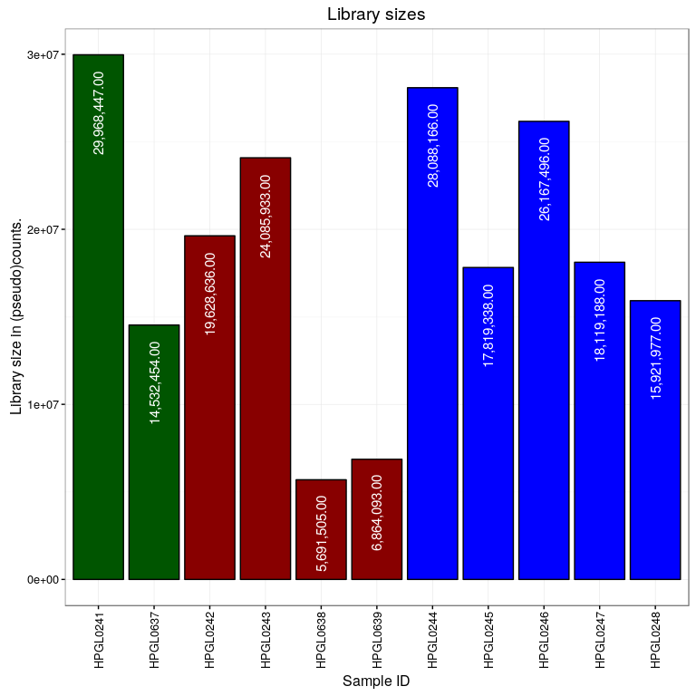

```r
print(hs_metrics$libsize)
```

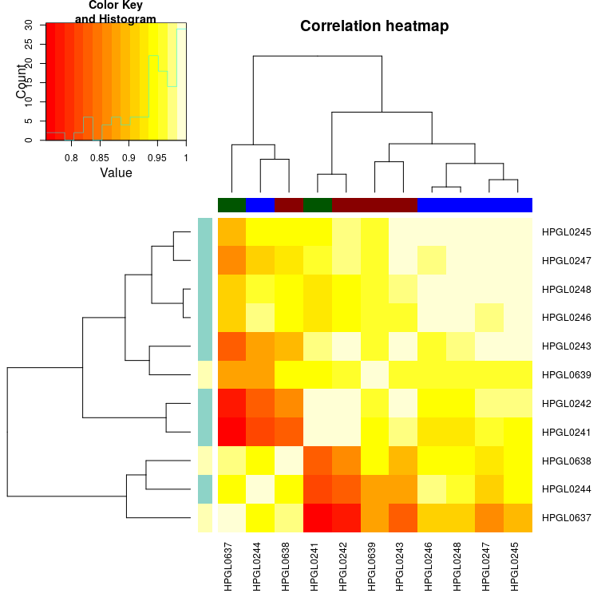

```r
## The samples numbered >600 have smaller libraries.

print(hs_metrics$corheat)
```

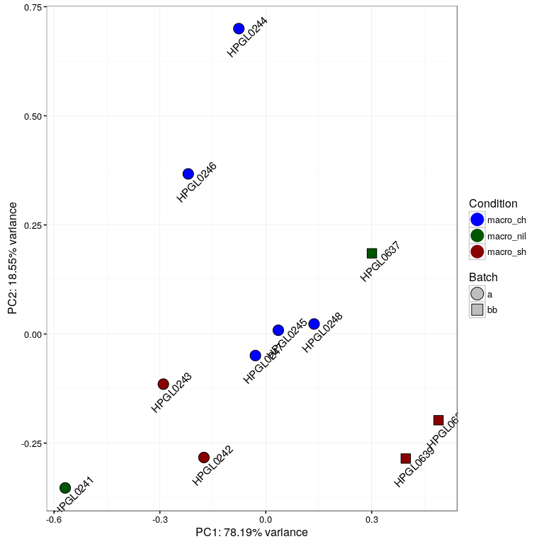

```r
## Oddly though, they correlate in clusters which suggest something else is going on.

print(hs_metrics$pcaplot)
```

```r
## But the new batch (squares) clearly segregates separately.
```